# Manual de Ambientación de Servidor con Tomcat utilizando Docker

Este manual tiene como objetivo guiar la configuración de un servidor con **Tomcat**, colocando los contenedores en el directorio `/home` en lugar de `/root`.

**Requisitos previos:**

- El servidor debe contar con un sistema operativo linux funcional.
- El servidor debe de contar con internet para la instalación de docker
- Debes conocer las credenciales del servidor para conectarte vía SSH o SCP.

# FASE 1: Actualización del Servidor e Instalación de Docker

### 1. Acceder al servidor vía SSH

Iniciamos sesión en el servidor para comenzar la configuración.

bash

```bash
# Conectarse al servidor por SSH usando el usuario y la IP correspondientes
ssh <usuario_servidor>@<ip_del_servidor>
```

**Ejemplo de uso:**

bash

```bash
ssh cgestionappprod@40.0.0.42
```

### 2. Verificar la distribución de Linux instalada

Identificamos la distribución para seguir la guía de instalación adecuada.

bash

```bash
# Muestra detalles del sistema operativo actual
cat /etc/os-release
```

### 3. Actualizar el sistema operativo

Una vez identificada la distribución (por ejemplo, **Rocky Linux 9.5**, compatible con RHEL/CentOS), se debe ejecutar el comando de actualización correspondiente. En el caso de Rocky/CentOS/RHEL, se utiliza `dnf`.

bash

```bash
# Actualiza todos los paquetes del sistema operativo
sudo dnf update
```

### 4. Reiniciar el servidor tras la actualización

Una vez finalizada la actualización del sistema, es recomendable reiniciar para asegurar que todos los cambios se apliquen correctamente. Esperar unos minutos antes de volver a ingresar via SSH

bash

```bash
# Reinicia el servidor
sudo reboot
```

### 5. Instalar Docker

La instalación debe seguir la guía oficial correspondiente a la distribución detectada.

- [Guía oficial de instalación de Docker para CentOS](https://docs.docker.com/engine/install/centos/)

> ⚠️ Se recomienda usar siempre las instrucciones oficiales para asegurar compatibilidad.

### 6. Verificar el estado del servicio Docker

En lugar de usar `hello-world`, que puede fallar por temas de red o restricciones del servidor, validamos directamente si el servicio Docker se encuentra en ejecución.

Al ejecutar el siguiente comando, el estado del servicio debe mostrarse en **color verde** con el mensaje `active (running)`. Si en cambio aparece en **rojo** o **blanco**, es probable que haya ocurrido un error durante la instalación y se recomienda revisar los pasos previos o consultar los logs del servicio.

bash

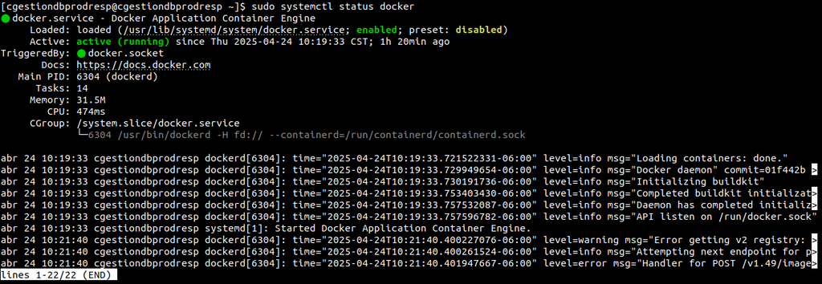

```bash
# Verifica si el servicio Docker está activo y en ejecución
sudo systemctl status docker
```

### 7. Configurar Docker para ejecutarse sin `sudo`

Se recomienda agregar el usuario actual al grupo `docker` para evitar anteponer `sudo` en cada comando.

bash

```bash
# Añade el usuario actual al grupo 'docker'
sudo usermod -aG docker ${USER}

# Inicia una nueva sesión para aplicar los cambios de grupo
su - ${USER}

# Muestra los grupos del usuario para confirmar que 'docker' fue agregado
groups
```

## FASE 2: Descarga de Imágenes y Transferencia al Servidor

### 8. Descarga de imagen desde Docker Hub

Debido a que el servidor puede presentar restricciones de red (como puertos bloqueados o acceso limitado a internet), se recomienda realizar la descarga de las imágenes necesarias desde una **computadora local** que tenga acceso completo a la red.

Para descargar correctamente la imagen, primero se debe identificar la versión deseada en [Docker Hub](https://hub.docker.com/), y posteriormente utilizar el comando `docker pull` desde la terminal.

- **Tomcat:** Buscar “Tomcat” en [Docker Hub](https://hub.docker.com/) y seleccionar la que tiene la etiqueta **Docker Official Image**.

Al ejecutar `docker pull` sin especificar versión, se descargará automáticamente la **última versión disponible** de la imagen. Si se desea una versión específica, es necesario indicarla explícitamente siguiendo el formato `<imagen>:<versión>`, según la lista de etiquetas disponibles en Docker Hub.

bash

```bash
# Descarga la imagen desde Docker Hub
docker pull <imagen>
```

**Ejemplo de uso:**

bash

```bash
# Descargar la imagen oficial de Tomcat 10 desde Docker Hub
docker pull tomcat:10
```

### 9. Exportar la imagen a archivos `.tar`

Esto permite trasladar la imagen al servidor sin conexión a internet.

bash

```bash
# Guarda la imagen en un archivo .tar
docker save -o <nombre_archivo>.tar <nombre_o_id_imagen>

# Verificar los archivos creados
ls
```

**Ejemplo de uso:**

bash

```bash
# Guarda la imagen de tomcat en un archivo .tar
docker save -o tomcat-10.tar tomcat:10
```

### 10. Transferir archivo `.tar` al servidor

Utilizar `scp` o herramientas como FileZilla para subir los archivos al directorio `/home/usuario` del servidor.

bash

```bash
# Envía los archivos .tar al servidor vía SCP
scp <archivo>.tar <usuario>@<ip_del_servidor>:/home/<usuario>/
```

**Ejemplo de uso:**

bash

```bash
# Envía el archivos postgres17-4.tar al servidor vía SCP
scp tomcat-10.tar cgestionappprod@40.0.0.42:/home/cgestionappprod/
```

## FASE 3: Cargar la imagen al docker

### 11. Acceder al servidor y realizar validaciones básicas

Inicia sesión en el servidor y verifica:

- Que los archivos `.tar` estén presentes.
- Que Docker esté instalado.
- Que el servicio de Docker esté activo.
- Que haya suficiente espacio disponible en disco.

bash

```bash
# Conectarse al servidor por SSH
ssh <usuario_servidor>@<ip_del_servidor>

# Verificar si esta el .tar
ls

# Verificar espacio disponible
df -lh

# Verificar instalación de Docker
docker --version

# Verifica que el servicio de Docker esté activo
sudo systemctl status docker
```

**Ejemplo de uso:**

bash

```bash
ssh cgestionappprod@40.0.0.42
```

### 12. Cargar la imagen al Docker del servidor

Es recomendable cargar una imagen a la vez y luego continuar con el paso 13 antes de subir la siguiente.

Al subir la imagen a Docker, esta es posible que no tenga el nombre ni etiqueta por defecto. Por ello, se recomienda realizar el proceso de una en una para evitar confusiones al asignar nombre y tag (ver paso 13).

bash

```bash
# Carga la imagen en Docker desde el archivo .tar
docker load -i <archivo.tar>
```

**Ejemplo de uso:**

bash

```bash
# Carga la imagen de tomcat en Docker desde el archivo .tar
docker load -i tomcat-10.tar
```

### 13. Renombrar etiquetas (tags) de la imagen

Al cargar la imagen, es posible que aparezcan como `<none>`. Es importante asignar un nombre y etiqueta adecuados para facilitar su uso.

bash

```bash
# Lista las imágenes disponibles y sus IDs
docker images

# Cambia el tag de una imagen usando su ID
docker tag <id_imagen> <nombre>:<etiqueta>
```

**Ejemplo de uso:**

bash

```bash
# Cambiar el nombre y etiqueta de postgres
docker tag f49abb9855df tomcat:10
```

### 14. Eliminar el archivo `.tar` luego de cargar la imagen al Docker

Una vez que la imagen ha sido correctamente cargada en Docker, es buena práctica eliminar los archivos `.tar` para liberar espacio en disco.

bash

```bash
# Elimina el archivo .tar del directorio home una vez cargado en Docker
rm <archivo>.tar
```

**Ejemplo de uso:**

bash

```bash
# Eliminar archivo de tomcat
rm tomcat-10.tar
```

## FASE 4: Crear contenedor

### 15. Crear estructura de carpetas para organizar contenedores

Para mantener un control claro y ordenado de los archivos relacionados a cada contenedor, se recomienda crear una estructura de carpetas dentro del directorio `/home/usuario/`. Esto facilita la gestión cuando se tienen múltiples versiones o instancias de un mismo tipo de contenedor (por ejemplo, varias versiones de PostgreSQL).

**Estructura recomendada:**

command-block

```
/home/usuario/
└── contenedor-tomcat
```

bash

```bash
# Crear carpeta principal para contenedores PostgreSQL
mkdir <ruta_carpeta>
```

**Ejemplo de uso:**

bash

```bash
mkdir contenedor-tomcat
```

### 16. Crear contenedor temporal de Tomcat

Se ejecuta un contenedor temporal basado en la imagen oficial de Tomcat para extraer su estructura y montar el entorno de forma persistente en `/home`.

bash

```bash
# Crear contenedor temporal
docker run --name <nombre_contenedor> <nombre>:<etiqueta>
```

**Ejemplo de uso:**

bash

```bash
docker run --name temp-tomcat tomcat:10
```

**Si aparece un mensaje como:**

bash

```bash
07-May-2025 17:45:02.623 INFO [main] org.apache.catalina.startup.Catalina.start Server startup in [49] milliseconds
```

Presiona `Ctrl + C` para salir de la consola del contenedor y luego ejecuta:

bash

```bash
# Iniciar nuevamente el contenedor en segundo plano
docker start <nombre_contenedor>
```

**Ejemplo de uso:**

bash

```bash
docker start temp-tomcat
```

Si no aparece el mensaje, seguir con el paso 17

### 17. Copiar archivos internos del contenedor temporal

Se copiará la carpeta del Tomcat desde el contenedor temporal hacia la carperta que creamos en el paso 15.

bash

```bash
# Copiar el contenido de Tomcat del contenedor a la nueva carperta
docker cp <nombre_contenedor_temporal>:/usr/local/tomcat <ubicacion_carpeta>
```

**Ejemplo de uso:**

bash

```bash
docker cp temp-tomcat:/usr/local/tomcat /home/cgestionappprod/contenedor-tomcat/
```

### 18. Asignar permisos de usuario a la carperta copiada

Es importante asegurarse de que los archivos tengan el usuario y grupo adecuados (ID 1000), para evitar problemas de permisos al ejecutar el contenedor definitivo.

bash

```bash
# Asignar permisos al directorio copiado
chown -R 1000:1000 <ruta_carperta_copiada>
```

**Ejemplo de uso:**

bash

```bash
chown -R 1000:1000 /home/cgestionappprod/contenedor-tomcat/tomcat
```

### 19. Eliminar el contenedor temporal

Vamos a eliminar el contenedor temporal, ya que no lo necesitaremos más.

bash

```bash
# Eliminar el contenedor temporal
docker rm -f <nombre_contenedor_temporal>
```

**Ejemplo de uso:**

bash

```bash
docker rm -f temp-tomcat
```

### 20. Crear el contenedor definitivo de Tomcat

Se crea el contenedor final de Tomcat montando la carpeta persistente previamente copiada. Este contenedor quedará corriendo en segundo plano y usará los puertos 8080 (HTTP) y 443 (HTTPS).

bash

```bash
# Crear y ejecutar el contenedor final de Tomcat con configuración persistente
docker run -d \
  --name <nombre_contenedor> \
  -p 8080:8080 \
  -p 443:443 \
  -v <ruta_carpeta_tomcat>:/usr/local/tomcat \
  <nombre_imagen>:<etiqueta_imagen>
```

**Ejemplo de uso:**

bash

```bash
docker run -d \
  --name tomcat \
  -p 8080:8080 \
  -p 443:443 \
  -v /home/cgestionappprod/contenedor-tomcat/tomcat:/usr/local/tomcat \
  tomcat:10
```

### 21. Verificar que el contenedor esté funcionando

Es crucial asegurarse de que el contenedor esté corriendo al menos 10 segundos y que sus logs no presenten errores. Esta verificación permite confirmar que el contenedor no se detiene inmediatamente por una mala configuración o error de ejecución.

El tiempo que lleva activo un contenedor puede observarse en la **columna STATUS** que aparece al ejecutar el comando `docker ps`. Si el contenedor ha estado “Up” por más de unos segundos, indica que se encuentra estable.

bash

```bash
# Mostrar contenedores activos
docker ps

# Ver logs del contenedor
docker logs <nombre_contenedor>
```

**Ejemplo de uso:**

bash

```bash
docker logs tomcat
```

### 22. Establecer reinicio automático de contenedores

Esto permite configurar todo contenedor en ejecución para que se reinicien automáticamente si el servidor se reinicia o el contenedor falla.

bash

```bash
# Establece la política de reinicio automático en todos los contenedores en ejecución
docker update --restart unless-stopped $(docker ps -q)
```

ó

bash

```bash
# Establece la política de reinicio automático 1 por 1
docker update --restart unless-stopped <id_contenedor>
```

Para estar más seguros, se pueden ejecutar ambos comandos.

## FASE 5: Configuracion rol e interfaz

### 23. Ingresar al Contenedor Docker

Primero, identificamos el ID del contenedor donde se encuentra instalado Tomcat:

bash

```bash
docker ps
```

Luego, accedemos al contenedor utilizando el siguiente comando:

bash

```bash
# Acceder a la carpeta /bash de nuestro contenedor
docker exec -it <id_contenedor> /bin/bash
```

**Ejemplo de uso:**

bash

```bash
docker exec -it e722df0f81ea /bin/bash
```

### 24. Acceder a la Carpeta `webapps.dist`

Dentro del contenedor, navegamos a la carpeta donde se encuentran los archivos de la aplicación por defecto de Tomcat:

bash

```bash
cd webapps.dist/
```

### 25. Copiar Archivos a la Carpeta `webapps`

Copiamos todo el contenido de `webapps.dist` a la carpeta `webapps`, que es donde Tomcat carga las aplicaciones:

bash

```bash
cp -R * ../webapps

cd ..
```

### 26. Verificar Archivos Copiados y Salir del Contenedor

Confirmamos que los archivos se copiaron correctamente:

bash

```bash
cd webapps

ls
```

Si todo está en orden, salimos del contenedor:

bash

```bash
exit
```

### 27. Comprobar Funcionamiento de la Aplicación

Desde un navegador web, accedemos a la dirección IP del servidor y al puerto configurado (por lo general, el **8080**). La URL tendrá el siguiente formato:

command-block

```
http://<IP_DEL_SERVIDOR>:<PUERTO>/
```

> Por ejemplo: `http://192.168.1.100:8080/`

Deberías ver la página principal de Tomcat cargada correctamente.

[figure not shown]

### 28. Configurar Acceso a Paneles `Server Status` y `Manager App`

Para habilitar el acceso a los botones **Server Status** y **Manager App**, realizamos las siguientes modificaciones:

#### a. Editar `tomcat-users.xml`

Abre el archivo de configuración de usuarios de Tomcat:

bash

```bash
nano <ruta>/tomcat/conf/tomcat-users.xml
```

**Ejemplo de uso:**

bash

```bash
nano /home/cgestionappprod/contenedor-tomcat/tomcat/conf/tomcat-users.xml
```

Agrega las siguientes líneas dentro de la etiqueta `<tomcat-users>`:

xml

```xml
<role rolename="manager-gui"/>
<user username="<usuario>" password="<contraseña>" roles="manager-gui"/>
```

#### b. Editar `context.xml` para permitir acceso remoto

Abre el archivo de configuración de acceso remoto:

bash

```bash
nano <tomcat>/tomcat/webapps/manager/META-INF/context.xml
```

**Ejemplo de uso:**

bash

```bash
nano /home/cgestionappprod/contenedor-tomcat/tomcat/webapps/manager/META-INF/context.xml
```

Comenta o elimina la línea que restringe el acceso por IP, específicamente la que contiene `Valve`:

xml

```xml
  <!--<Valve className="org.apache.catalina.valves.RemoteAddrValve"
         allow="127\.\d+\.\d+\.\d+|::1|0:0:0:0:0:0:0:1" />-->
```

Esto permitirá acceder al panel desde cualquier IP.

### 29. Reiniciar el Contenedor (Opcional pero Recomendado)

Para aplicar los cambios correctamente, se recomienda reiniciar el contenedor:

bash

```bash
docker restart <id_contenedor>
```

## ¡Listo! Con esto queda finalizado el despliegue de Tomcat en tu servidor con Docker.